```python
from google.colab import drive
drive.mount('/content/drive')
```

# **Our mission**

In order to provide meaningful analysis of LendingClub's customers, we first need to understand a little bit about the business and several key questions. LendingClub is a peer-to-peer loan provider, meaning they allow people to apply for loans, and other individuals or companies to furfil those loans. LendingClub itself needs not finance any loans with their own money, but has a responsability to its customers to verify that those who are applying for loans have the ability to pay in a timely manner. You can therefor think of LendingClub's role in these transactions as a credit auditor.

The core queston for LendingClub becomes "Who can repay their loans?". To support this question, we first ask severl other questions:

```
Who is getting loans?
What kind of loans are being given out?
How accurate is LendingClubs loan grading system?
What data points are important in determining if someone will repay?
```

After answering these questions, we explore making accurate machine learning algorithims and attempt to answer our core question.

# **Data processing**

The first step to understanding our data is to clean up our data and identify columns that are important or not important.

```python
# Import basic data science packages
import pandas as pd
import seaborn as sns
import numpy as np
import matplotlib.pyplot as plt
import matplotlib
%matplotlib inline

# Import map visulization libraries
import chart_studio.plotly as py
import plotly.graph_objs as go
from plotly import tools
from plotly.offline import download_plotlyjs, init_notebook_mode, plot, iplot
init_notebook_mode(connected=True)

def categorize(l):
    uniques = sorted(list(set(l)))
    return [uniques.index(x) + 1 for x in l]
```

```python
path = "/content/drive/MyDrive/CSV FILES/accepted_2007_to_2018Q4.csv"
df = pd.read_csv(path)
```

```python
df.head()
```

|  | id | member_id | loan_amnt | funded_amnt | funded_amnt_inv | term | int_rate | installment | grade | sub_grade | emp_title | emp_length | home_ownership | annual_inc | verification_status | issue_d | loan_status | pymnt_plan | url | desc | purpose | title | zip_code | addr_state | dti | delinq_2yrs | earliest_cr_line | fico_range_low | fico_range_high | … |
| --- | --- | --- | --- | --- | --- | --- | --- | --- | --- | --- | --- | --- | --- | --- | --- | --- | --- | --- | --- | --- | --- | --- | --- | --- | --- | --- | --- | --- | --- | --- |
| 0 | 68407277 | NaN | 3600.0 | 3600.0 | 3600.0 | 36 months | 13.99 | 123.03 | C | C4 | leadman | 10+ years | MORTGAGE | 55000.0 | Not Verified | Dec-2015 | Fully Paid | n | https://lendingclub.com/browse/loanDetail.acti... | NaN | debt_consolidation | Debt consolidation | 190xx | PA | 5.91 | 0.0 | Aug-2003 | 675.0 | 679.0 | … |
| 1 | 68355089 | NaN | 24700.0 | 24700.0 | 24700.0 | 36 months | 11.99 | 820.28 | C | C1 | Engineer | 10+ years | MORTGAGE | 65000.0 | Not Verified | Dec-2015 | Fully Paid | n | https://lendingclub.com/browse/loanDetail.acti... | NaN | small_business | Business | 577xx | SD | 16.06 | 1.0 | Dec-1999 | 715.0 | 719.0 | … |
| 2 | 68341763 | NaN | 20000.0 | 20000.0 | 20000.0 | 60 months | 10.78 | 432.66 | B | B4 | truck driver | 10+ years | MORTGAGE | 63000.0 | Not Verified | Dec-2015 | Fully Paid | n | https://lendingclub.com/browse/loanDetail.acti... | NaN | home_improvement | NaN | 605xx | IL | 10.78 | 0.0 | Aug-2000 | 695.0 | 699.0 | … |
| 3 | 66310712 | NaN | 35000.0 | 35000.0 | 35000.0 | 60 months | 14.85 | 829.90 | C | C5 | Information Systems Officer | 10+ years | MORTGAGE | 110000.0 | Source Verified | Dec-2015 | Current | n | https://lendingclub.com/browse/loanDetail.acti... | NaN | debt_consolidation | Debt consolidation | 076xx | NJ | 17.06 | 0.0 | Sep-2008 | 785.0 | 789.0 | … |
| 4 | 68476807 | NaN | 10400.0 | 10400.0 | 10400.0 | 60 months | 22.45 | 289.91 | F | F1 | Contract Specialist | 3 years | MORTGAGE | 104433.0 | Source Verified | Dec-2015 | Fully Paid | n | https://lendingclub.com/browse/loanDetail.acti... | NaN | major_purchase | Major purchase | 174xx | PA | 25.37 | 1.0 | Jun-1998 | 695.0 | 699.0 | … |

5 rows × 151 columns

```python
df.tail()
```

|  | id | member_id | loan_amnt | funded_amnt | funded_amnt_inv | term | int_rate | installment | grade | sub_grade | emp_title | emp_length | home_ownership | annual_inc | verification_status | issue_d | loan_status | pymnt_plan | url | desc | purpose | title | zip_code | addr_state | dti | delinq_2yrs | earliest_cr_line | fico_range_low | fico_range_high | … |
| --- | --- | --- | --- | --- | --- | --- | --- | --- | --- | --- | --- | --- | --- | --- | --- | --- | --- | --- | --- | --- | --- | --- | --- | --- | --- | --- | --- | --- | --- | --- |
| 2260696 | 88985880 | NaN | 40000.0 | 40000.0 | 40000.0 | 60 months | 10.49 | 859.56 | B | B3 | Vice President | 9 years | MORTGAGE | 227000.0 | Verified | Oct-2016 | Current | n | https://lendingclub.com/browse/loanDetail.acti... | NaN | debt_consolidation | NaN | 907xx | CA | 12.75 | 7.0 | Feb-1995 | 705.0 | 709.0 | … |
| 2260697 | 88224441 | NaN | 24000.0 | 24000.0 | 24000.0 | 60 months | 14.49 | 564.56 | C | C4 | Program Manager | 6 years | RENT | 110000.0 | Not Verified | Oct-2016 | Charged Off | n | https://lendingclub.com/browse/loanDetail.acti... | NaN | debt_consolidation | Debt consolidation | 334xx | FL | 18.30 | 0.0 | Jul-1999 | 660.0 | 664.0 | … |
| 2260698 | 88215728 | NaN | 14000.0 | 14000.0 | 14000.0 | 60 months | 14.49 | 329.33 | C | C4 | Customer Service Technician | 10+ years | MORTGAGE | 95000.0 | Verified | Oct-2016 | Current | n | https://lendingclub.com/browse/loanDetail.acti... | NaN | debt_consolidation | NaN | 770xx | TX | 23.36 | 0.0 | Jun-1996 | 660.0 | 664.0 | … |
| 2260699 | Total amount funded in policy code 1: 1465324575 | NaN | NaN | NaN | NaN | NaN | NaN | NaN | NaN | NaN | NaN | NaN | NaN | NaN | NaN | NaN | NaN | NaN | NaN | NaN | NaN | NaN | NaN | NaN | NaN | NaN | NaN | NaN | NaN | … |
| 2260700 | Total amount funded in policy code 2: 521953170 | NaN | NaN | NaN | NaN | NaN | NaN | NaN | NaN | NaN | NaN | NaN | NaN | NaN | NaN | NaN | NaN | NaN | NaN | NaN | NaN | NaN | NaN | NaN | NaN | NaN | NaN | NaN | NaN | … |

5 rows × 151 columns

```python
df.shape
```

```
(2260701, 151)
```

```python
df.describe()
```

|  | member_id | loan_amnt | funded_amnt | funded_amnt_inv | int_rate | installment | annual_inc | dti | delinq_2yrs | fico_range_low | fico_range_high | inq_last_6mths | mths_since_last_delinq | mths_since_last_record | open_acc | pub_rec | revol_bal | revol_util | total_acc | out_prncp | out_prncp_inv | total_pymnt | total_pymnt_inv | total_rec_prncp | total_rec_int | total_rec_late_fee | recoveries | collection_recovery_fee | last_pymnt_amnt | … |
| --- | --- | --- | --- | --- | --- | --- | --- | --- | --- | --- | --- | --- | --- | --- | --- | --- | --- | --- | --- | --- | --- | --- | --- | --- | --- | --- | --- | --- | --- | --- |
| count | 0.0 | 2.260668e+06 | 2.260668e+06 | 2.260668e+06 | 2.260668e+06 | 2.260668e+06 | 2.260664e+06 | 2.258957e+06 | 2.260639e+06 | 2.260668e+06 | 2.260668e+06 | 2.260638e+06 | 1.102166e+06 | 359156.000000 | 2.260639e+06 | 2.260639e+06 | 2.260668e+06 | 2.258866e+06 | 2.260639e+06 | 2.260668e+06 | 2.260668e+06 | 2.260668e+06 | 2.260668e+06 | 2.260668e+06 | 2.260668e+06 | 2.260668e+06 | 2.260668e+06 | 2.260668e+06 | 2.260668e+06 | … |
| mean | NaN | 1.504693e+04 | 1.504166e+04 | 1.502344e+04 | 1.309283e+01 | 4.458068e+02 | 7.799243e+04 | 1.882420e+01 | 3.068792e-01 | 6.985882e+02 | 7.025884e+02 | 5.768354e-01 | 3.454092e+01 | 72.312842 | 1.161240e+01 | 1.975278e-01 | 1.665846e+04 | 5.033770e+01 | 2.416255e+01 | 4.206891e+03 | 4.205965e+03 | 1.208256e+04 | 1.206439e+04 | 9.505772e+03 | 2.431388e+03 | 1.518453e+00 | 1.438791e+02 | 2.398257e+01 | 3.429346e+03 | … |
| std | NaN | 9.190245e+03 | 9.188413e+03 | 9.192332e+03 | 4.832138e+00 | 2.671735e+02 | 1.126962e+05 | 1.418333e+01 | 8.672303e-01 | 3.301038e+01 | 3.301124e+01 | 8.859632e-01 | 2.190047e+01 | 26.464094 | 5.640861e+00 | 5.705150e-01 | 2.294831e+04 | 2.471307e+01 | 1.198753e+01 | 7.343239e+03 | 7.342333e+03 | 9.901383e+03 | 9.896992e+03 | 8.321852e+03 | 2.679738e+03 | 1.184159e+01 | 7.481640e+02 | 1.312256e+02 | 6.018248e+03 | … |
| min | NaN | 5.000000e+02 | 5.000000e+02 | 0.000000e+00 | 5.310000e+00 | 4.930000e+00 | 0.000000e+00 | -1.000000e+00 | 0.000000e+00 | 6.100000e+02 | 6.140000e+02 | 0.000000e+00 | 0.000000e+00 | 0.000000 | 0.000000e+00 | 0.000000e+00 | 0.000000e+00 | 0.000000e+00 | 1.000000e+00 | 0.000000e+00 | 0.000000e+00 | 0.000000e+00 | 0.000000e+00 | 0.000000e+00 | 0.000000e+00 | -9.500000e-09 | 0.000000e+00 | 0.000000e+00 | 0.000000e+00 | … |
| 25% | NaN | 8.000000e+03 | 8.000000e+03 | 8.000000e+03 | 9.490000e+00 | 2.516500e+02 | 4.600000e+04 | 1.189000e+01 | 0.000000e+00 | 6.750000e+02 | 6.790000e+02 | 0.000000e+00 | 1.600000e+01 | 55.000000 | 8.000000e+00 | 0.000000e+00 | 5.950000e+03 | 3.150000e+01 | 1.500000e+01 | 0.000000e+00 | 0.000000e+00 | 4.546458e+03 | 4.531800e+03 | 3.000000e+03 | 7.281875e+02 | 0.000000e+00 | 0.000000e+00 | 0.000000e+00 | 3.103300e+02 | … |
| 50% | NaN | 1.290000e+04 | 1.287500e+04 | 1.280000e+04 | 1.262000e+01 | 3.779900e+02 | 6.500000e+04 | 1.784000e+01 | 0.000000e+00 | 6.900000e+02 | 6.940000e+02 | 0.000000e+00 | 3.100000e+01 | 74.000000 | 1.100000e+01 | 0.000000e+00 | 1.132400e+04 | 5.030000e+01 | 2.200000e+01 | 0.000000e+00 | 0.000000e+00 | 9.329720e+03 | 9.309675e+03 | 7.000000e+03 | 1.525940e+03 | 0.000000e+00 | 0.000000e+00 | 0.000000e+00 | 6.005700e+02 | … |
| 75% | NaN | 2.000000e+04 | 2.000000e+04 | 2.000000e+04 | 1.599000e+01 | 5.933200e+02 | 9.300000e+04 | 2.449000e+01 | 0.000000e+00 | 7.150000e+02 | 7.190000e+02 | 1.000000e+00 | 5.000000e+01 | 92.000000 | 1.400000e+01 | 0.000000e+00 | 2.024600e+04 | 6.940000e+01 | 3.100000e+01 | 6.149940e+03 | 6.146310e+03 | 1.694087e+04 | 1.691671e+04 | 1.389910e+04 | 3.108062e+03 | 0.000000e+00 | 0.000000e+00 | 0.000000e+00 | 3.743750e+03 | … |
| max | NaN | 4.000000e+04 | 4.000000e+04 | 4.000000e+04 | 3.099000e+01 | 1.719830e+03 | 1.100000e+08 | 9.990000e+02 | 5.800000e+01 | 8.450000e+02 | 8.500000e+02 | 3.300000e+01 | 2.260000e+02 | 129.000000 | 1.010000e+02 | 8.600000e+01 | 2.904836e+06 | 8.923000e+02 | 1.760000e+02 | 4.000000e+04 | 4.000000e+04 | 6.329688e+04 | 6.329688e+04 | 4.000000e+04 | 2.819250e+04 | 1.484340e+03 | 3.985955e+04 | 7.174719e+03 | 4.219205e+04 | … |

8 rows × 113 columns

# **Data Cleaning**

We've identified several columns that fit into one of the following categories:

```
Unneccesary data such as the URL to view the loan
Redundant data. Loan description may be useful to some, but the much more conciese loan purpose fits our needs
User provided information. Employer titles may offer some insight into employment industry, but would need significant cleanup to provide useful statistics
Operational data. The next payment date for the loan at the time the data was generated is not relevant to us
```

```python
# Drop unneccesary columns
df = df.drop(['url', 'desc', 'policy_code', 'last_pymnt_d', 'next_pymnt_d', 'earliest_cr_line', 'emp_title'], axis=1)
df = df.drop(['id', 'title', 'total_rec_int', 'total_rec_late_fee', 'total_rec_prncp', 'zip_code'], axis=1)
df = df.drop(['revol_bal_joint','sec_app_fico_range_low','sec_app_fico_range_high','sec_app_earliest_cr_line','sec_app_inq_last_6mths','sec_app_mort_acc','sec_app_open_acc','sec_app_revol_util'], axis=1)
df = df.drop(['sec_app_open_act_il','sec_app_num_rev_accts','sec_app_chargeoff_within_12_mths','sec_app_collections_12_mths_ex_med','sec_app_mths_since_last_major_derog'], axis=1)
df = df.drop(['hardship_flag','hardship_type','hardship_reason','hardship_status', 	'deferral_term','hardship_amount','hardship_start_date'], axis=1)
df = df.drop(['hardship_end_date','payment_plan_start_date', 'hardship_length', 'hardship_dpd', 'hardship_loan_status','orig_projected_additional_accrued_interest'], axis=1)
df = df.drop(['hardship_payoff_balance_amount', 'hardship_last_payment_amount'], axis=1)
df = df.drop(['debt_settlement_flag_date', 	'settlement_status', 	'settlement_date', 	'settlement_amount', 	'settlement_percentage', 	'settlement_term','member_id'], axis=1)
```

```python
df.head()
```

|  | loan_amnt | funded_amnt | funded_amnt_inv | term | int_rate | installment | grade | sub_grade | emp_length | home_ownership | annual_inc | verification_status | issue_d | loan_status | pymnt_plan | purpose | addr_state | dti | delinq_2yrs | fico_range_low | fico_range_high | inq_last_6mths | mths_since_last_delinq | mths_since_last_record | open_acc | pub_rec | revol_bal | revol_util | total_acc | … |
| --- | --- | --- | --- | --- | --- | --- | --- | --- | --- | --- | --- | --- | --- | --- | --- | --- | --- | --- | --- | --- | --- | --- | --- | --- | --- | --- | --- | --- | --- | --- |
| 0 | 3600.0 | 3600.0 | 3600.0 | 36 months | 13.99 | 123.03 | C | C4 | 10+ years | MORTGAGE | 55000.0 | Not Verified | Dec-2015 | Fully Paid | n | debt_consolidation | PA | 5.91 | 0.0 | 675.0 | 679.0 | 1.0 | 30.0 | NaN | 7.0 | 0.0 | 2765.0 | 29.7 | 13.0 | … |
| 1 | 24700.0 | 24700.0 | 24700.0 | 36 months | 11.99 | 820.28 | C | C1 | 10+ years | MORTGAGE | 65000.0 | Not Verified | Dec-2015 | Fully Paid | n | small_business | SD | 16.06 | 1.0 | 715.0 | 719.0 | 4.0 | 6.0 | NaN | 22.0 | 0.0 | 21470.0 | 19.2 | 38.0 | … |
| 2 | 20000.0 | 20000.0 | 20000.0 | 60 months | 10.78 | 432.66 | B | B4 | 10+ years | MORTGAGE | 63000.0 | Not Verified | Dec-2015 | Fully Paid | n | home_improvement | IL | 10.78 | 0.0 | 695.0 | 699.0 | 0.0 | NaN | NaN | 6.0 | 0.0 | 7869.0 | 56.2 | 18.0 | … |
| 3 | 35000.0 | 35000.0 | 35000.0 | 60 months | 14.85 | 829.90 | C | C5 | 10+ years | MORTGAGE | 110000.0 | Source Verified | Dec-2015 | Current | n | debt_consolidation | NJ | 17.06 | 0.0 | 785.0 | 789.0 | 0.0 | NaN | NaN | 13.0 | 0.0 | 7802.0 | 11.6 | 17.0 | … |
| 4 | 10400.0 | 10400.0 | 10400.0 | 60 months | 22.45 | 289.91 | F | F1 | 3 years | MORTGAGE | 104433.0 | Source Verified | Dec-2015 | Fully Paid | n | major_purchase | PA | 25.37 | 1.0 | 695.0 | 699.0 | 3.0 | 12.0 | NaN | 12.0 | 0.0 | 21929.0 | 64.5 | 35.0 | … |

5 rows × 103 columns

Additionally, we identified some rows that we decided were not relevant to our needs. The 'loan_status' column is the source of our answer to the core question if people are paying the loans they take out. We found some records with a loan_status of "Does not meet the credit policy". We believe these may be older loans that would simply not be accepted under LendingClubs current criteria. As these data points will provide no value moving forward, we've ecluded them from our data. Similiarily, recently issued loans could mislead our analysis, as no payment has been expected yet.

```python
#Checking the overall percent of null values
missing=df.isnull().sum()
total_cells=np.product(df.shape)
total_missing=missing.sum()

percent_missing=(total_missing/total_cells)*100
print(percent_missing)
```

```
12.727269752307219
```

```python
i = len(df)
df = pd.DataFrame(df[df['loan_status'] != "Does not meet the credit policy. Status:Fully Paid"])
df = pd.DataFrame(df[df['loan_status'] != "Does not meet the credit policy. Status:Charged Off"])
df = pd.DataFrame(df[df['loan_status'] != "Issued"])
df = pd.DataFrame(df[df['loan_status'] != "In Grace Period"])
a = len(df)
print(f"We dropped {i-a} rows, a {((i-a)/((a+i)/2))*100}% reduction in rows")
```

```
We dropped 11185 rows, a 0.49598500471263357% reduction in rows
```

```python
df.info()
```

[output not shown]

A significant amount of data remains, and we will move forward with the following columns remaining

# **Analysis**

We first begin to look at our data to better understand our demographics. We start by taking a look at the length of employment for our customers.

```python
# make temporary dataframe in order to keep original dataframe
df_copy = df.copy()
df_copy["emp_length"] = ["0.5" if x == '< 1 year' else x for x in df_copy["emp_length"]]

# check employment length
df_copy.emp_length.unique()
```

```
array(['10+ years', '3 years', '4 years', '6 years', '1 year', '7 years',
       '8 years', '5 years', '2 years', '9 years', '0.5', nan],
      dtype=object)
```

What we need to know:

```
Understand what amount was mostly issued to borrowers.
Which year issued the most loans.
The distribution of loan amounts is a multinomial distribution .
```

Summary:

[output not shown]

# **Good Loans vs Bad Loans:**

In this section, we will see what is the amount of bad loans Lending Club has declared so far, of course we have to understand that there are still loans that are at a risk of defaulting in the future.

What we need to know:

```
The amount of bad loans could increment as the days pass by, since we still have a great amount of current loans.
Average annual income is an important key metric for finding possible opportunities of investments in a specific region.
```

Summary:

[output not shown]

```python
df["loan_status"].value_counts()
```

[output not shown]

```python
# Determining the loans that are bad from loan_status column

bad_loan = ["Charged Off", "Default", "Does not meet the credit policy. Status:Charged Off", "In Grace Period",
            "Late (16-30 days)", "Late (31-120 days)"]


df['loan_condition'] = np.nan

def loan_condition(status):
    if status in bad_loan:
        return 'Bad Loan'
    else:
        return 'Good Loan'


df['loan_condition'] = df['loan_status'].apply(loan_condition)
```

```
[Text(0, 0.5, '(%)')]
```

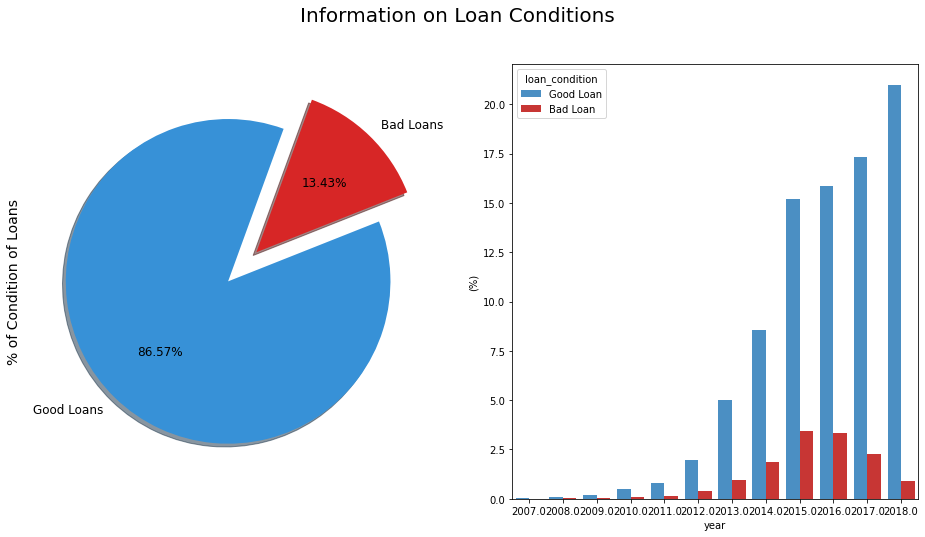

```python
f, ax = plt.subplots(1,2, figsize=(16,8))

colors = ["#3791D7", "#D72626"]
labels ="Good Loans", "Bad Loans"

plt.suptitle('Information on Loan Conditions', fontsize=20)

df["loan_condition"].value_counts().plot.pie(explode=[0,0.25], autopct='%1.2f%%', ax=ax[0], shadow=True, colors=colors,
                                             labels=labels, fontsize=12, startangle=70)


# ax[0].set_title('State of Loan', fontsize=16)
ax[0].set_ylabel('% of Condition of Loans', fontsize=14)

# sns.countplot('loan_condition', data=df, ax=ax[1], palette=colors)
# ax[1].set_title('Condition of Loans', fontsize=20)
# ax[1].set_xticklabels(['Good', 'Bad'], rotation='horizontal')
palette = ["#3791D7", "#E01E1B"]

sns.barplot(x="year", y="loan_amnt", hue="loan_condition", data=df, palette=palette, estimator=lambda x: len(x) / len(df) * 100)
ax[1].set(ylabel="(%)")
```

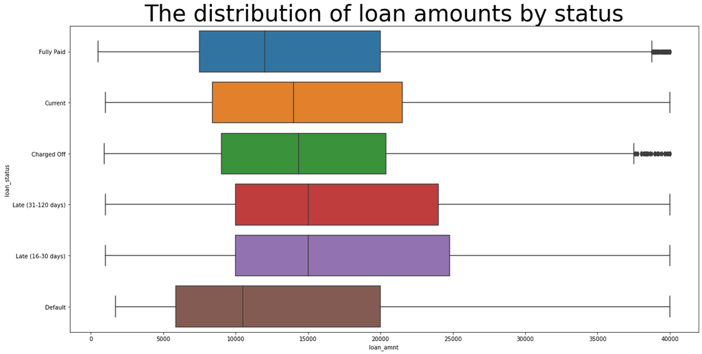

```python
# Loan amount by its status
plt.subplots(figsize=(20,10))
plt.title("The distribution of loan amounts by status").set_size(40)
sns.boxplot(x="loan_amnt", y="loan_status", data=df_copy)
```

Summary

[output not shown]